# Infections in Patients with Hemtalogical Malignancies

**Russell E. Lewis**  
Associate Professor of Infectious Diseases  
Department of Molecular Medicine  
University of Padua

[figure not shown]

russelledward.lewis@unipd.it  
[https://github.com/Russlewisbo](https://github.com/Russlewisbo/ESCMID_2022_talk)

## Objectives

- What are the most common infections associated with short versus prolonged neutropenia?
- What are the unique risks of infection associated with targeted therapies?
- How does the presentation of skin, mucocutaneous lesions, abdominal pain or pneumonia change the infection differential diagnosis?
- What are common empiric antimicrobial regimens used to treat patients while awaiting diagnostic results?

## Agenda

- Classic infection risk factors and management
- Current role of fluoroquinolone prophylaxis
- What is the impact of new targeted therapies on infection risk?
- Pneumonia and invasive fungal diseases

**Note**

Will focus mostly on epidemiology and general management principles > specific drug therapy.

## Effects of chemotherapy on hematopoiesis

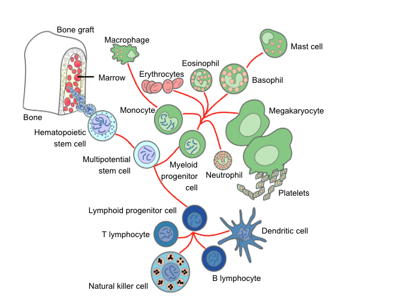

Virtually all antineoplastic agents impair proliferation of hematopoietic progenitor cells, resulting in dose-limiting **anemia**, **thrombocytopenia** and **neutropenia**.

**Neutrophils**

- Short-lived, post-mitotic cells
- Continuously repopulated
- Complete re-population 14–21 days after chemotherapy

**Lymphocytes**

- Heterogeneous — short- and long-lived cells
- Considerable mitotic expansion
- Restoration of heterogeneous populations and T-cell competence is slow and often incomplete

## Causes of death at the dawn of the chemotherapy era for leukemia

| Parameter | 1954– 1959, n (%) | 1960– 1963, n(%) | *p* |
| --- | --- | --- | --- |
| Patients | 184 | 170 |  |
| Hemorrhage alone | 40 (22) | 25 (14) | <0.001 |
| Infection alone | 45 (24) | 80 (44) | <0.001 |
| Infections (total) | 124 (67) | 131 (71) | NS |
| *S. aureus* | 30 (24) | 6 (5) | <0.001 |
| *E. coli* | 27 (22) | 17 (13) | NS |
| *Klebsiella* spp. | 9 (7) | 16 (12) | NS |
| *P. aeruginosa* | 31 (25) | 45 (34) | NS |
| Fungi | 10 (8) | 30 (23) | <0.001 |
| Other | 24 (13) | 23 (12) | NS |

(Bodey, 2009; Hersh et al., 1965; Raab et al., 1960)

## Fungal infections at the dawn of the chemotherapy era

**Insights from autopsy studies**

- 189 fungal infections in 161/454 patients (35%)
- Most infections diagnosed *after* death
- 127 invasive fungal infections:
  - Invasive candidiasis (n = 73)
  - Aspergillosis (n = 38)
  - Mucormycosis (n = 6)

**Risk factors:** prolonged neutropenia, corticosteroids.

(Bodey, 2009, 1966)

## The vanishing medical autopsy

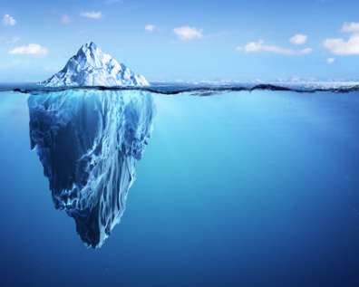

**Autopsy rates over two decades — M.D. Anderson Cancer Center**

- 1989–1993: 63%
- 2004–2008: **6%**
- In 2004–2008, **45%** of patients with proven aspergillosis at autopsy had persistently negative galactomannan results.

(Chamilos et al., 2006; Lewis et al., 2013)

## Available antibiotics at the dawn of the chemotherapy era

**Warning**

**No effective agents for *Pseudomonas aeruginosa*!**

- Penicillin G
- Erythromycin
- Chloramphenicol
- Tetracyclines
- Polymyxins
- Neomycin
- Streptomycin
- Kanamycin
- Vancomycin
- Ristocetin
- Novobiocin
- Sulfas

## Prevalent attitudes in hematology wards in the 1960s

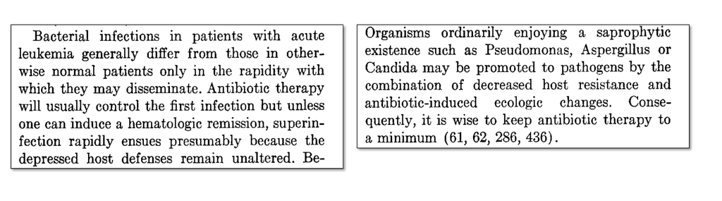

“It is useless to aggressively treat infections if the leukemia patient is not in remission.”

(Boggs et al., 1962)

## Impact of carbenicillin on *P. aeruginosa* septicaemia in leukemic patients

**MD Anderson Cancer Center, Houston, Texas USA**

| Clinical presentation | 1965–68 Cure (%) | 1972–81 Cure (%) |
| --- | --- | --- |
| Overall | 21 | 62 |
| Shock | 0 | 25 |
| Pneumonia | 0 | 49 |
| Persistent neutropenia | 6 | 41 |
| Persistent bacteremia | 14 | 21 |

Slide: Dr. Gerald Bodey

## Absolute neutrophil count predicts the risk of infection

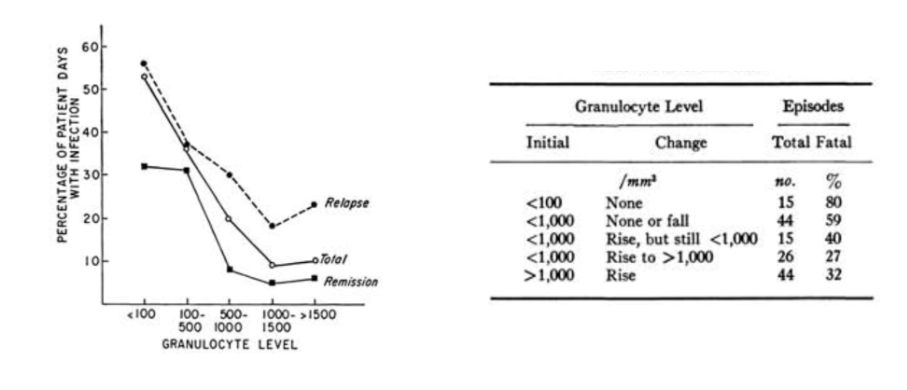

**The pioneering study of Dr. Gerald Bodey at the NCI**

- 10–25% of patients have active bacteremia.

(Bodey et al., 1966)

## Absolute neutrophil count

$$\text{ANC} = \text{WBC} \times \frac{(\%\ \text{neutrophils} + \%\ \text{bands})}{100}$$

| **ANC (cells/µL)** | **Interpretation** | **Clinical relevance** |
| --- | --- | --- |
| 1000–1500 | Mild neutropenia | Usually low risk |
| 500–1000 | Moderate | Increased infection risk |
| **<500** | Severe neutropenia | High risk of serious infections |
| **<100** | Profound | Extremely high risk |

- The ANC correlates directly with risk of bacterial and fungal infections
- Below 500/µL, endogenous flora becomes dangerous (gut, skin)
- Below 100/µL, risk becomes very high, especially with prolonged duration

## Clinical signs of infection are muted in neutropenic patients

*% of patients with the indicated neutrophil count/mm³*

| Signs and symptoms | <100 | 101–1000 | >1000 |
| --- | --- | --- | --- |
| Fever | 98 | 90 | 76 |
| Fluctuance | 6 | 36 | 52 |
| Fissure or ulceration | 21 | 42 | 54 |
| Exudate | 11 | 64 | 91 |
| Purulent sputum | 8 | 67 | 84 |
| Pyuria | 11 | 63 | 97 |

(Sickles et al., 1975)

## Empiric antimicrobial therapy

**A standard of care in febrile neutropenia**

“Beginning broad-spectrum empirical antibiotic therapy at the first sign of fever in a profoundly neutropenic patient can be life-saving and has been a standard of therapy for nearly 5 decades.”

**Fever** (≥ 38.0° C) **and** **neutropenia** (≤ 0.5 × 10<sup>9</sup> cells/L)

↓

**IV antibiotics:**  
Empiric monotherapy (any of the following)

- Piperacillin/tazobactam
- Anti-pseudomonal carbapenem
- Ceftazidime
- Cefepime

↓

**Adjust antimicrobials based on specific radiographic and/or culture data**, *e.g.*

- Vancomycin/daptomycin or linezolid for cellulitis or pneumonia
- Switch to carbapenem for pneumonia with Gram-negative bacteremia
- Oral vancomycin for abdominal symptoms or suspected *C. difficile*
- Antifungal therapy if persistent fever > 72 hours on antibiotics

(Pizzo, 2019)

## Impact of improved supportive care

**Mortality during the first treatment month of acute myelogenous leukemia (*n* = 9 380)**

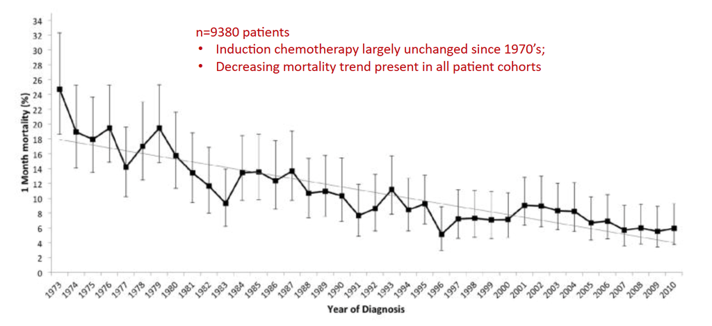

- Induction chemotherapy largely unchanged since the 1970s.
- Decreasing mortality trend present in **all** patient cohorts.

(Percival et al., 2015)

## Pillars of hemato-oncology treatment

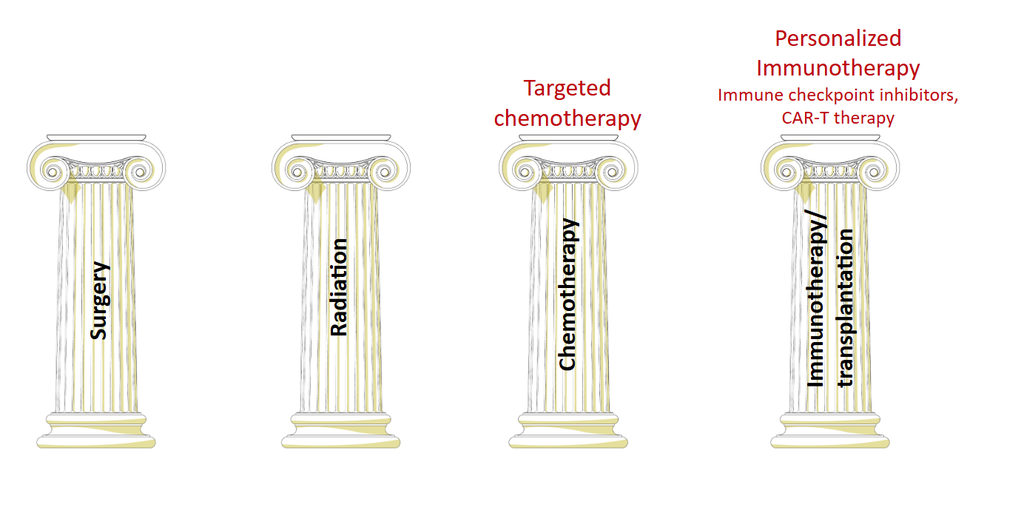

# Pathogenesis and epidemiology

## Pathogenesis of infection during neutropenia

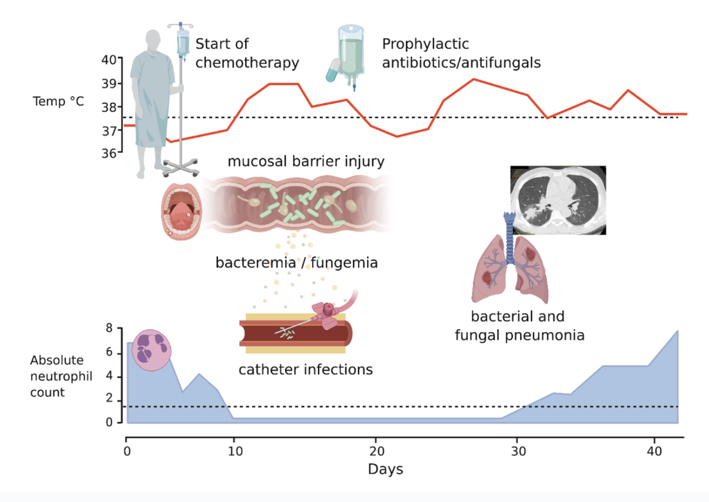

## Chemotherapy-associated dysbiosis and mucosal barrier injury

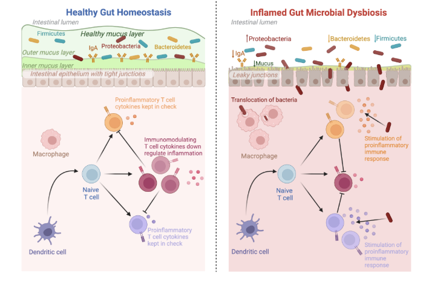

## Mucositis

**WHO oral toxicity scale**

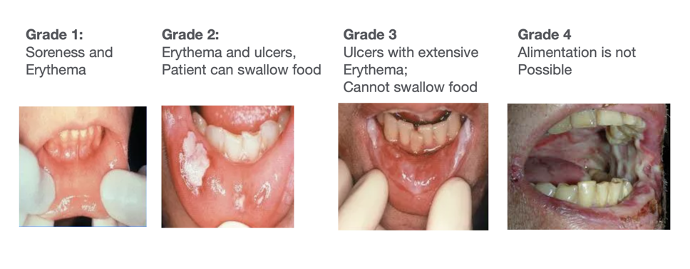

## GI tract is the major source of bacteremia

**Gram-negative bacilli**

*Aerobic*

- *Pseudomonas aeruginosa*

*Facultatively anaerobic*

- *Escherichia coli*
- *Klebsiella pneumoniae*
- *Enterobacter cloacae*

*Capnophilic*

- *Capnocytophaga* species

*Anaerobic*

- *Fusobacterium* species
- *Leptotrichia buccalis*
- *Prevotella* species

**Gram-positive cocci**

*Oral viridans streptococci*

- *Streptococcus mitis*
- *Streptococcus oralis*
- *Streptococcus sanguis*

*Staphylococci*

- *Staphylococcus epidermidis*

*Others*

- *Stomatococcus mucilaginosus*

## Causes of fever complicating induction chemotherapy

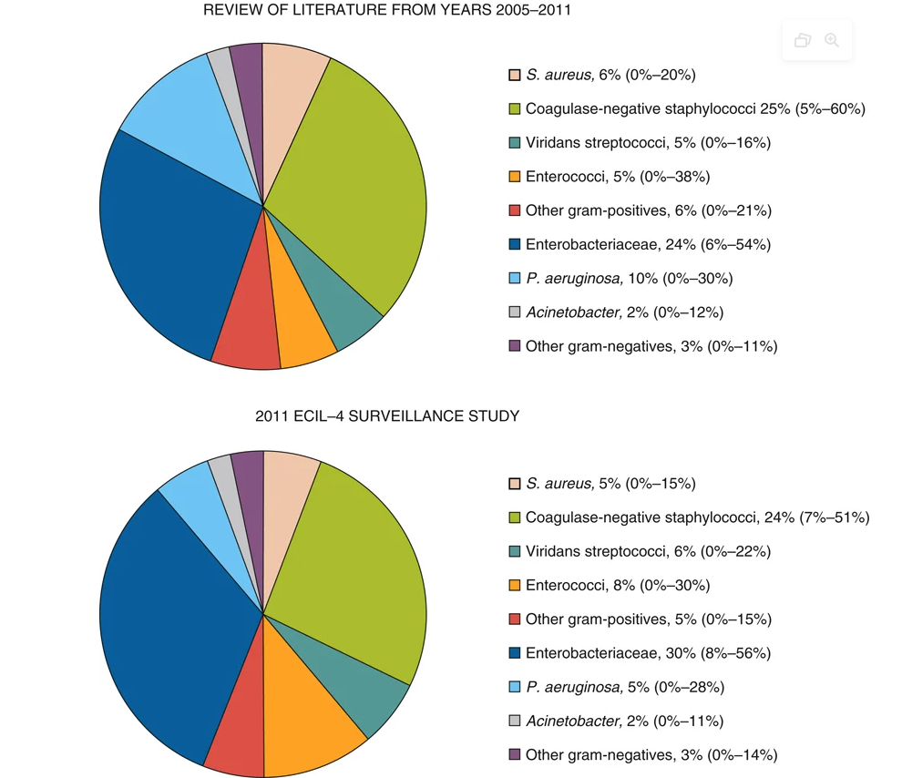

## Vesicular lesions, mucosal ulcers and thrush

**HSV / VZV reactivation and *Candida* mucosal infections**

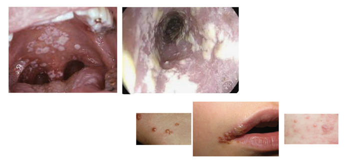

## Skin lesions in neutropenic patients

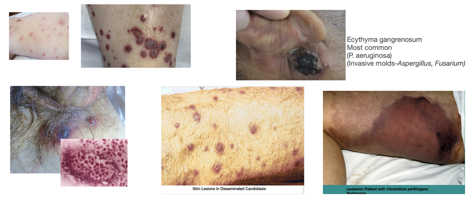

## Ecthyma gangrenosum lesions

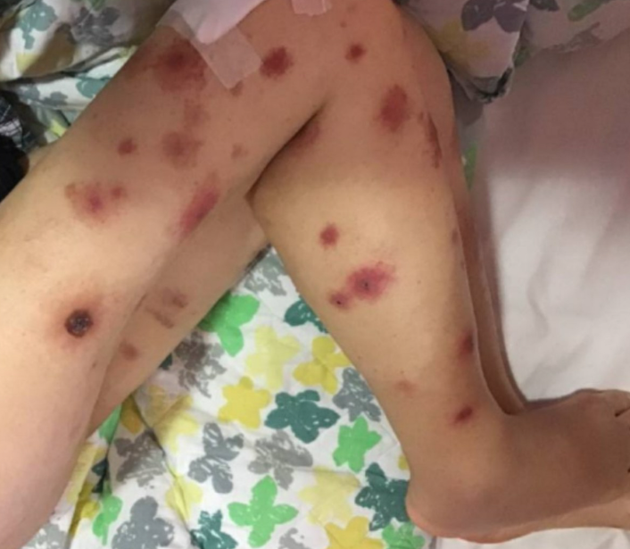

**Tip**

**Biopsy!**

## *Clostridium difficile* and neutropenic colitis

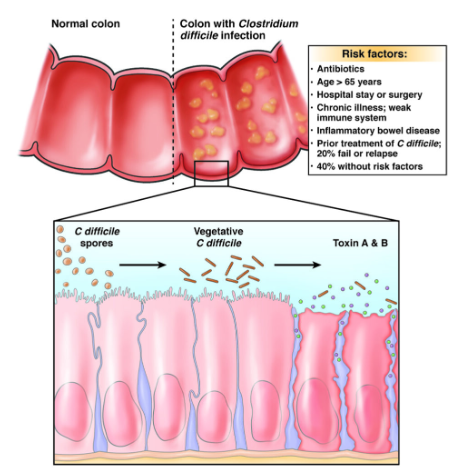

- Diarrhea is common — both infectious and non-infectious causes
  - Chemotherapy-associated mucosal injury
  - Neutropenic enterocolitis
  - Drugs (e.g., oral magnesium supplements)
- *C. difficile*-associated diarrhea (CDAD): incidence 10–30% in some studies
- Oral vancomycin, fidaxomicin > metronidazole
- Limited data for FMT, bezlotoxumab

(Alonso et al., 2012)

## Pathogenesis of infection during neutropenia

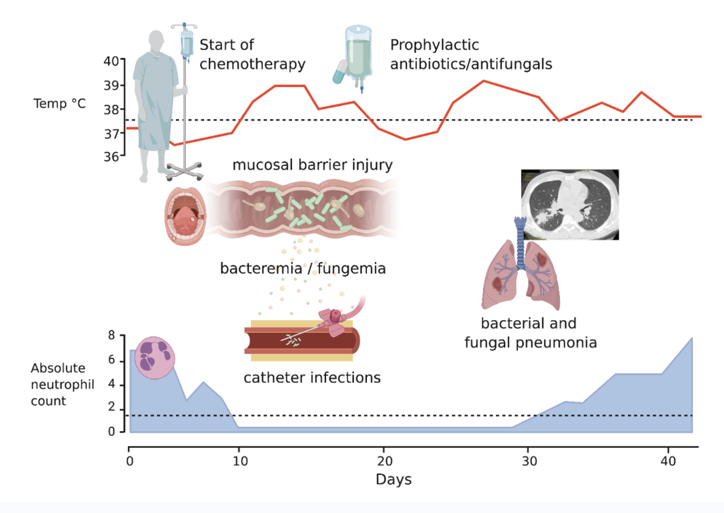

## Lung infiltrates in leukemia patients

**Urgent CT imaging needed!**

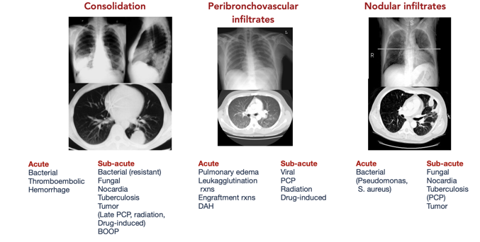

## Bronchoscopy: timing is critical

**Early microbiological diagnosis is associated with improved mortality**

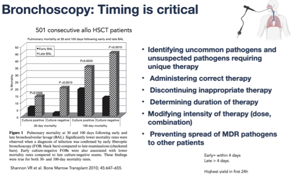

## Infection risk versus duration of neutropenia

**Phase I (1–10 days)**

- Herpes simplex
- ± *Candida*

**Phase II (10–27 days)**

- CoNS *Staphylococcus*
- Enterobacteriaceae
- Viridans streptococci
- Anaerobes
- *Enterococcus*
- *C. difficile*
- Herpes simplex / *Candida*

**Phase III (>27 days)**

- MRSA
- VRE
- Resistant GNR
- *S. maltophilia*
- Invasive moulds

(Safdar and Armstrong, 2001)

## BLI combination comparison

| Feature | Ceftolozane-Tazobactam | Ceftaz-Avibactam | Cefiderocol |
| --- | --- | --- | --- |
| MDR *Pseudomonas* | ++++ | ++ | +++ |
| ESBL | +++ | ++++ | +++ |
| KPC | - | ++++ | +++ |
| MBL | - | - | ++ |
| OXA-48 | - | ++++ | +++ |
| *Acinetobacter* | + | + | ++++ |

Agent selection depends on the specific resistance mechanism present.

## Rectal swab to detect MDR colonization

Rectal swab surveillance identifies patients at highest risk of MDR-related bloodstream infection (BSI) during neutropenia.

| Feature | ESBL-*E* | CR-*Klebsiella* (KPC) | MDR *P. aeruginosa* |
| --- | --- | --- | --- |
| **Prevalence at admission** (HM inpatients) | Most common MDR-GNB | ~3–6% in high-endemicity areas | Variable; rising in Italy and SE Europe |
| **Colonization → concordant BSI** | ~14–16% | ~14% | Up to 20–25% |
| **BSI occurs mainly during…** | Neutropenia (87% of cases) | Neutropenia | Neutropenia / mucositis |
| **3-month overall survival** (colonized) | 96.8% | 83.6% | High mortality if inadequate therapy |
| **Empiric therapy modification** | Carbapenem | Ceftazidime/avibactam or meropenem/vaborbactam | Ceftolozane/tazobactam or ceftazidime/avibactam |

**Important**

**Risk of MDR-related BSI is ~38-fold higher** in rectal carriers vs. non-colonized patients. Weekly rectal surveillance in high-risk wards enables pathogen-directed empiric therapy and antibiotic stewardship.

(Baccelli et al., 2025; Cattaneo et al., 2018; Gallardo-Pizarro et al., 2025; Luo et al., 2024)

## *P. aeruginosa* ST175 and ST23 outbreak in the hematology ward in Bologna

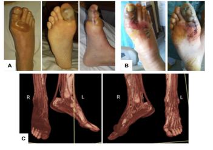

Required temporary suspension of admissions and cleaning of water systems and traps.

(Coppola et al., 2020)

# Is fluoroquinolone prophylaxis still useful?

## Is fluoroquinolone prophylaxis still useful?

**International guidelines on FQ prophylaxis**

| Author, Year | Organization | Population | Recommendation |
| --- | --- | --- | --- |
| Bucaneve, 2007 | ECIL-1 | NP, high-risk | ✅ FQP recommended |
| Freifeld, 2011 | IDSA | NP, high-risk | ✅ FQP recommended |
| Slavin, 2011 | Victorian Integrated Cancer Services, Australia | NP, high-risk | ⚠️ FQP **not** recommended (lack of mortality benefit; resistance risk) |
| Baden, 2012 | NCCN | NP, high-risk | ✅ FQP recommended |
| NICE, 2012 | NICE | NP, high-risk | ✅ FQP recommended |
| Klastersky, 2016 | ESMO | NP, high-risk | ⚠️ FQP **not** recommended |
| Taplitz, 2018 | ASCO/IDSA | NP, high-risk | ✅ FQP recommended |
| Mikulska, 2018 | ECIL, EBMT, EORTC, ICHS, ELN | NP, high-risk | 🔵 Consider locally whether benefits on BSI/FN outweigh resistance and toxicity risks |
| Christopeit, 2021 | AGIHO | HDC and auto-HSCT | 🔵 Weigh expected benefits against risks (local epidemiology and individual patient factors) |

NP, neutropenic patients; HDC, high-dose chemotherapy; FQP, fluoroquinolone prophylaxis.

## Do all patients benefit from FQ prophylaxis / BSI reduction?

**Prospective study (4 223 alloHSCT, 3 602 autoHSCT, 930 acute leukemia on HDS, 2009–2014)**

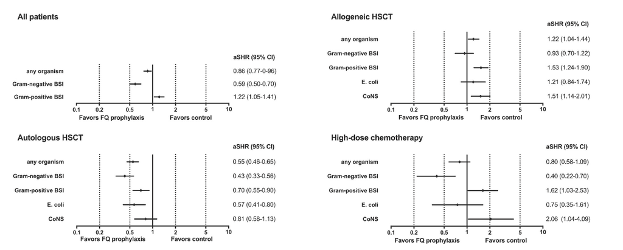

(Kern et al., 2018)

## FQ-resistant *Enterobacterales* colonization reduces FQ-prophylaxis effectiveness

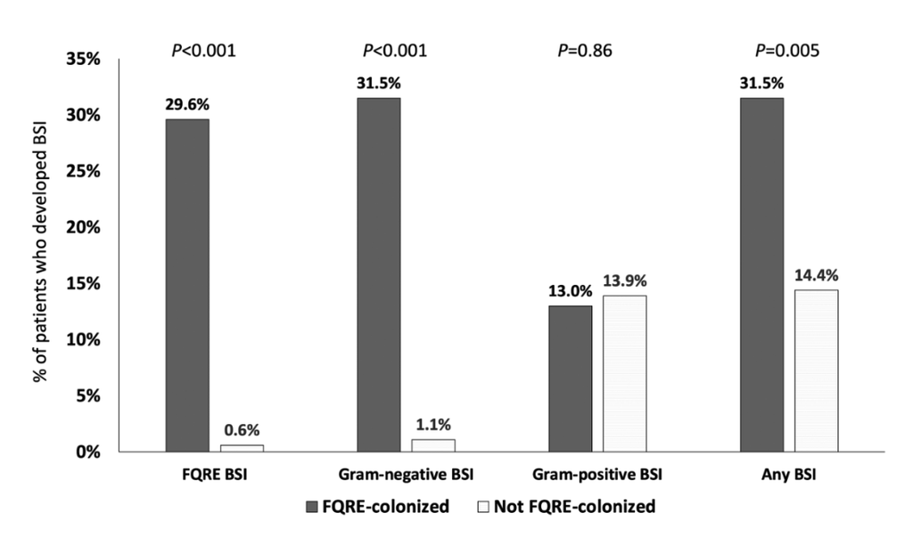

(Satlin et al., 2021)

## Squeezing the resistance balloon

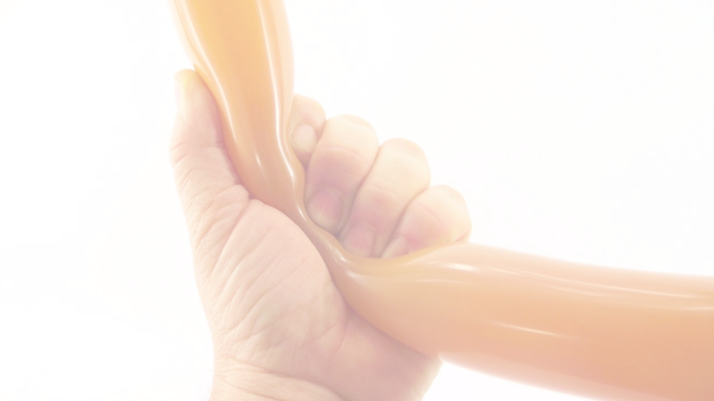

1. Chemotherapy- and antibiotic-associated dysbiosis
2. Fluoroquinolone prophylaxis
3. ESBL colonization
4. Empiric carbapenem therapy to cover ESBLs
5. Colonization with carbapenem-producing *Enterobacterales*
6. **Carbapenem-resistant bloodstream infections**

ECIL-10 systematic review confirms a **south-eastern European resistance gradient** and a significant temporal increase in ESBL/3GCR, CR *K. pneumoniae*, and MDR *P. aeruginosa* over the past decade. (Baccelli et al., 2025)

## To give or not to give fluoroquinolone prophylaxis?

**Why YES?**

- Less neutropenic fever events
- Less bloodstream infections

**Why NO?**

- No difference in mortality?
- Reduced efficacy in high-resistance settings
- Infection with MDR and FQ-resistant bacteria
- Adverse events (↑ QTc, etc.)
- *Clostridium difficile*
- Effect on gut microbiota

**Note**

*But*… effect depends on FQ-resistance rate, FQR colonization, FQ type, and underlying disease.

## What is the future?

- Personal approach directed by **screening** (not universal prophylaxis)
- Improved sepsis diagnosis and management
- Individual risk score (Big data)
- RCTs in high-resistance locations
- Additional data on outcomes (CDI, resistance emergence, microbiome changes)

(Slavin et al., 2019)

# How long to treat?

**Classic dogma:** continue antibiotics until resolution of neutrophil count *irrespective* of fever response.

## “How Long” study

(Aguilar-Guisado et al., 2017)

## “How Long”: key findings

- FUO patients afebrile and clinically stable for 72 h after start of empiric therapy could safely stop antimicrobial therapy
- No difference in mortality, subsequent BSI or recurrent fever between intervention and control arms
- Antimicrobial-free days significantly higher in intervention arm (median 16.1 vs. 13.6 days)
- However, few alloHSCT patients enrolled
- Average duration of fever in intervention group: 24 h

(Aguilar-Guisado et al., 2017)

## De-escalating empiric antimicrobial therapy

**2011 4th European Conference on Infections in Leukemia recommendations**

**Patient stable at presentation and 76–96 h later**

*Afebrile (FUO):*

- Reevaluate appropriateness of antibiotic regimens
- Consider stopping aminoglycoside, fluoroquinolone, or Gram-positive agents
- Continue current β-lactam or consider switch to narrow-spectrum agent

*Clinically-documented infection:*

- Reevaluate antibiotic regimens
- Stop aminoglycosides, quinolone or Gram-positive agent if combined
- Switch to narrower spectrum if sensitive
- Consider stopping antibiotic treatment at ≥72 h if afebrile ≥48 h
- Complicated vs. uncomplicated infection!

**Patient deteriorating**

*Febrile:*

- Diagnostic work-up
- Consider resistant Gram-negative; empiric addition of colistin or other broader-spectrum agent
- Consider resistant Gram-positive pathogen; add appropriate therapy
- Consider fungal, viral, and other etiologies of deterioration

*Afebrile:*

- Diagnostic work-up
- Consider fungal and other atypical pathogens

FUO, fever of unknown origin.

(Averbuch et al., 2013)

## Real-world implementation of early de-escalation

**Empiric therapy (high-risk febrile neutropenia)**  
**Amikacin** 15 mg/kg/d IV — stop after 3 days if no MDR  
**Meropenem** 3 × 1 g/d IV (extended infusion 3 h)

→

**Add vancomycin if:**

- Gram+ blood cultures (≥ 2 sets)
- Catheter-related infection
- Skin / soft-tissue infection
- MRSA colonization

Loading 20 mg/kg → maintenance per CrCl/TDM · stop amikacin

↓ reassess every 24 h

Microbiologically  
documented infection  
*De-escalate* per resistance profile  
*Stop* after ≥ 7 days total,  
≥ 4 days afebrile, pathogen eradicated

Clinically documented  
infection  
*Stop* when all signs resolved,  
≥ 7 days total, ≥ 4 days afebrile  
*Pulmonary aspergillosis:* stop antibiotics if stable + > 48 h afebrile on antifungal

Fever of unknown  
origin (FUO)  
*Stop* after ≥ 72 h if clinically stable and afebrile ≥ 48 h  
No documented focus required

In case of **fever relapse**, reinitiate empiric therapy and draw blood cultures before restarting antibiotics.

(Verlinden et al., 2022)

# Unique infection risks with other immunosuppressive therapies

## “Net state of immunosuppression”

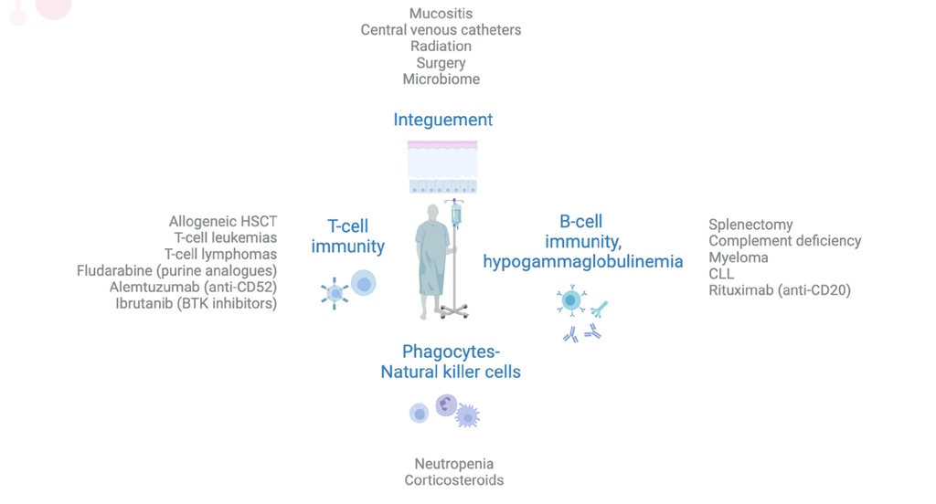

## Corticosteroids

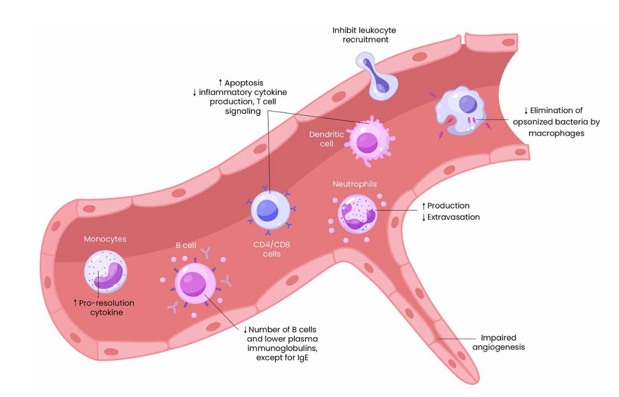

**The “credit cards” of immunosuppression**

(Chastain et al., 2023)

## Suppressed cell-mediated immunity

**Macrophages, CD4⁺ T-helper lymphocytes**

*Intracellular bacteria*

- *Mycobacterium tuberculosis*
- Atypical mycobacteria
- *Legionella* spp.
- *Listeria monocytogenes*
- *Salmonella typhi*
- *Nocardia* spp.

*Fungi*

- *Candida* spp.
- Rare yeast (echinocandin-resistant)
- Endemic fungi
- *Cryptococcus*
- *P. jirovecii*
- Molds

*Parasites*

- *Toxoplasma gondii*
- *Cryptosporidium*
- *Leishmania*

**CD8⁺ cytotoxic T-cells**

*Viruses*

- Herpes simplex
- Varicella zoster
- Cytomegalovirus
- HHV-6
- Epstein-Barr
- Adenovirus
- Polyomaviruses
- Influenza
- Para-influenza
- RSV

Drugs that suppress cell-mediated immunity: purine analogues (e.g., fludarabine, 2-CDA, clofarabine), alemtuzumab, corticosteroids (>20 mg prednisone equivalent for >2 weeks), TNF-α inhibitors…

## Leukemia progress: expansion of targeted therapies

| Disease | Current/future therapies | 5–10 yr survival |
| --- | --- | --- |
| Hairy-cell leukemia | Cladribine + rituximab | 90% |
| Acute promyelocytic leukemia | ATRA ± gemtuzumab ozogamicin (GO) | 80–90% |
| Core-binding-factor AML | FLAG-GO ± IDA; alloHSCT if MRD-positive | 80–90% |
| AML, younger / fit | FLAG-IDA + venetoclax; CLIA + venetoclax; FLT3/IDH inhibitors; HMA-based maintenance ± menin inhibitors | 50–60%+ |
| AML, older / unfit | Low-intensity triple nucleosides (cladribine, cytarabine, HMAs) + venetoclax; HMAs + venetoclax + targeted therapies | 40–50%? |
| ALL <60 y | Hyper-CVAD + CD19/CD22/CD20 antibodies | 60–70% |
| ALL >60 y | Mini-Hyper-CVAD, inotuzumab, blinatumomab | 50% |
| Ph⁺ ALL | Hyper-CVAD + ponatinib; ponatinib + blinatumomab | 70–80%? |
| CML | BCR-ABL1 TKIs (imatinib, dasatinib, bosutinib, nilotinib, ponatinib); alloHSCT | 85–90% |
| CLL | Ibrutinib / other BTKi (acalabrutinib, zanubrutinib, pirtobrutinib) | 80–90%+ |
| Higher-risk MDS | Parenteral / oral HMAs, venetoclax, others | 40%+ |

(H. Kantarjian et al., 2021; H. M. Kantarjian et al., 2021)

## Unexpected consequences?

**Ibrutinib: Bruton’s tyrosine kinase (BTK) inhibitor**

**RESONATE-2 Trial (frontline ibrutinib for CLL)**

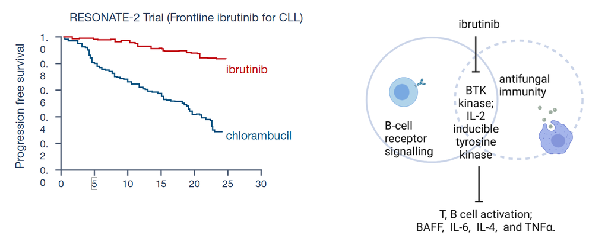

[output not shown]

(Burger et al., 2015)

## Aspergillosis associated with ibrutinib treatment

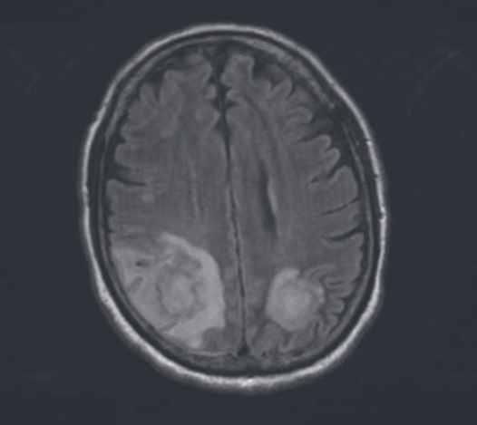

- Retrospective French surveillance (FILO): 33 cases of aspergillosis in ibrutinib-treated CLL patients
- CNS aspergillosis in 11/27 (40%); most cases within 3 months of starting ibrutinib
- All patients had refractory/relapsed disease and additional predisposing factors (e.g., steroids in 7, neutropenia in 5)
- T2-FLAIR MRI showing multiple cerebral abscesses

(Chamilos et al., 2018; Ghez et al., 2018)

## Fungal infections in patients receiving ibrutinib for lymphoid cancers

**MDACC retrospective (2014–2018), *n* = 841**

- 21 (2.5%) with proven/probable IFI
- Mostly pneumonia
- Primary fungus: *Aspergillus*
- IFI risk factors:
  - Monocytopenia (OR 6.00)
  - ≥3 prior CLL therapies (OR 5.36)

**MSKCC experience, *n* = 378**

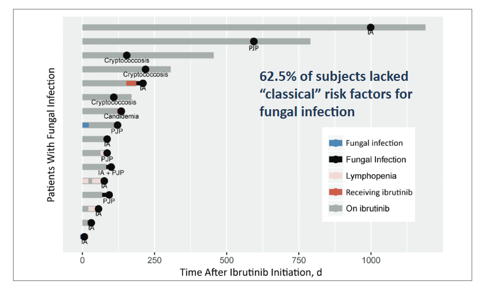

- 62.5% of subjects lacked “classical” risk factors for fungal infection.

(Frei et al., 2020; Varughese et al., 2018)

## Ibrutinib for steroid-refractory cGVHD

In the pivotal phase 1/2b studies, the most common adverse events were fatigue, diarrhea, muscle spasms, nausea, and bruising; relatively low incidence (18%) of pneumonia and only 1 case related to aspergillosis.

Limited “real-life” experience suggests higher rates of invasive fungal disease for steroid-refractory cGVHD:

- Overall response in SR-cGVHD: 9/11 (82%)
- Infections: 6/11 (55%)
- Possible/proven invasive aspergillosis: 4/11 (36%)

(Kaloyannidis et al., 2021; Miklos et al., 2017; Waller et al., 2019)

## Invasive fungal infection risk with targeted therapies

| Class | Relative IA incidence | Antifungal-prophylaxis / DDI considerations |
| --- | --- | --- |
| BiTE (blinatumomab) | Higher if post-alloHSCT, prolonged neutropenia, or CR — risk factors not reported | No known drug interactions |
| FLT3 inhibitors (midostaurin, gilteritinib) | No clear ↑ post-alloHSCT? | Avoid strong CYP3A4 inhibitors; ↑ 2–10-fold AUC with itraconazole; monitor QTc; posaconazole or isavuconazole with TDM; no routine dose adjustment |
| PI3Kδ (idelalisib) | ↑ risk of CMV, PJP, aspergillosis? | Avoid strong CYP3A4 inhibitors; ↑ 1.8-fold AUC with ketoconazole; monitor for toxicity |
| IDH 1/2 (ivosidenib, enasidenib) | No clear ↑ infection; distinguish infection from differentiation syndrome | Avoid strong CYP3A4 inhibitors; ↑ 2.7-fold AUC with itraconazole; monitor QTc |
| BCL-2 (venetoclax) | Possible ↑ risk (prolonged cytopenia) without prophylaxis | Dose-reduce venetoclax >50–75% if azole indicated; ↑ 8.8-fold AUC with posaconazole |
| HMAs (azacytidine, decitabine) | Lower in newly-treated patients; higher in refractory disease | Antifungal prophylaxis may not be needed initially; no triazole interactions |
| Hedgehog inhibitor (glasdegib) | No data | Avoid with azole; monitor QTc |

(Logan et al., 2020)

## Adverse-effect monitoring: toxicities of small-molecule inhibitors (SMIs)

**Warning**

Differential diagnosis should always include drug interactions in patients on triazoles.

(Wang and Baron, 2020)

## Chimeric antigen receptor T-cell therapy

## Infection risk with CAR-T therapy

- Lymphodepleting chemotherapy (cyclophosphamide, fludarabine) → mucosal damage
- CAR-T cells → cytokine release syndrome (CRS), ICANS
- Tocilizumab (anti-IL-6), corticosteroids
- Underlying disease and prior therapies → lymphopenia, hypogammaglobulinemia, neutropenia
- Risk windows:
  - **Bacterial infections** early
  - **Viral infections** through neutropenia recovery
  - **Fungal and other opportunistic infections** with prolonged neutropenia or corticosteroids

(Gudiol et al., 2021)

## Checkpoint inhibitors

**Toxicities may overlap with symptoms of infection.**

(Martins et al., 2019)

## Opportunistic infections during ICI / IRAE management

Retrospective study of 740 melanoma patients at MSKCC (2010–2014) receiving immune checkpoint blockers:

- Serious infection in 54 (7.3%); fungal infection in 6 (PJP 3, IPA 2)
- Average time to infection: 135 days; 80% within 6 months
- Risk factors: corticosteroids (OR 7.71), infliximab (OR 4.74)
- Combination ipilimumab + nivolumab: ↑ risk; pembrolizumab inversely associated

(Arriola et al., 2015; Del Castillo et al., 2016; Kyi et al., 2014; Uslu et al., 2015)

# Invasive fungal infections

## Problem: non-specificity of CT findings

Possible causes of similar CT appearance: *P. aeruginosa* · *Aspergillus* · *K. pneumoniae* · mould · CMV · *Cryptococcus* · lymphoma · *Nocardia*

## EORTC/MSG definitions of invasive fungal disease

**Epidemiology use only**

| Category | Required evidence |
| --- | --- |
| **Proven** | Direct evidence of fungal tissue invasion |
| **Probable** | Host factors + clinical factors + indirect mycological evidence (e.g., galactomannan) |
| **Possible** | Host factors + clinical factors |

(Donnelly et al., 2019)

## CT pulmonary angiography (CTPA) to improve specificity for invasive mold disease

**Fungal angioinvasion and vessel thrombosis**

(Bergeron et al., 2012; Sonnet et al., 2005; Stergiopoulou et al., 2007)

## CTPA distinguishes mold vs. bacterial pneumonia in acute leukemia

- **VOS positive:** proven mold disease by autopsy
- **VOS negative:** bacterial pneumonia
- VOS = vessel occlusion sign

(Stanzani et al., 2012)

## CTPA: case examples

- AML consolidation; neutropenia; posaconazole prophylaxis; serum GM negative → BAL: galactomannan 1.5 (VOS +)
- Resistant CML; neutropenia; posaconazole prophylaxis; serum GM negative → BAL: MDR *P. aeruginosa* +, GM − (VOS −)

## Fungal sinusitis / pneumonia: breakthrough infections on prophylaxis

Possible etiologies on prophylaxis breakthrough:

- Resistant *Aspergillus*?
- Mucorales
- *Fusarium* spp.
- *Scedosporium* spp.
- Rare yeast (e.g., *Saprochaete clavata*)

(Stanzani et al., 2019)

## Invasive mucormycosis

## CT-specific findings for mucormycosis?

- Multiple bilateral nodular infiltrates

# Final thoughts: what to do with persistent fever?

## Persistent fevers — what to do?

- **Wrong bug** (viruses? atypicals? *fungi*!)
- **Wrong drug** (MDR pathogen?)
- **Wrong process** (malignancy, transfusions, contrast, allergy, etc.)
- **No source control** (endocarditis? CLABSI, osteomyelitis, liver/abdominal abscess)
- **Not enough time?**

## Defervescence after start of effective antibiotics in neutropenic patients

(De Pauw et al., 1994; Ramphal et al., 1992)

## Summary

**Febrile neutropenia: infections in patients with hematological malignancies**

- Despite new targeted treatments and immunotherapy, principles of infection management — especially empiric therapy — are largely unchanged.
- Increasing focus on **earlier discontinuation** of therapy in afebrile, clinically stable patients.
- Imaging is progressing with **CT pulmonary angiography** and **FDG-PET** to support antibiotic stewardship; potential for *labeled PET* in the future.
- Unique risk for infections with novel therapies — an epidemiological black box.

## References

Aguilar-Guisado M, Espigado I, Martín-Peña A, Gudiol C, Royo-Cebrecos C, Falantes J, et al. Optimisation of empirical antimicrobial therapy in patients with haematological malignancies and febrile neutropenia (how long study): An open-label, randomised, controlled phase 4 trial. The Lancet Haematology 2017;4:e573–83.

Alonso CD, Treadway SB, Hanna DB, Huff CA, Neofytos D, Carroll KC, et al. Epidemiology and outcomes of *Clostridium difficile* infections in hematopoietic stem cell transplant recipients. Clinical Infectious Diseases 2012;54:1053–63.

Arriola E, Wheater M, Lopez MA, Thompson B, Ottensmeier C. Outcome and biomarker analysis from a multicenter phase 2 study of ipilimumab in combination with carboplatin and etoposide as first-line therapy for extensive-stage SCLC. OncoImmunology 2015.

Averbuch D, Orasch C, Cordonnier C, Livermore DM, Mikulska M, Viscoli C, et al. European guidelines for empirical antibacterial therapy for febrile neutropenic patients in the era of growing resistance: Summary of the 2011 4th european conference on infections in leukemia. Haematologica 2013;98:1826–35.

Baccelli F, Gudiol C, Garcia-Vidal C, Mikulska M, Maertens J, Blijlevens N, et al. Epidemiology of resistant bacterial infections in patients with haematological malignancies or undergoing haematopoietic cell transplantation in Europe: A systematic review by the European Conference on Infections in Leukemia (ECIL-10). The Lancet Regional Health – Europe 2025.

Bergeron A, Porcher R, Sulahian A, Bazelaire C de, Chagnon K, Raffoux E, et al. The strategy for the diagnosis of invasive pulmonary aspergillosis should depend on both the underlying condition and the leukocyte count of patients with hematologic malignancies. Blood 2012;119:1831–7.

Bodey GP. Infectious complications of acute leukemia: A historical perspective. Journal of Antimicrobial Chemotherapy 2009;63:i3–13.

Bodey GP. Fungal infections complicating acute leukemia. Journal of Chronic Diseases 1966;19:667–87.

Bodey GP, Buckley M, Sathe YS, Freireich EJ. Quantitative relationships between circulating leukocytes and infection in patients with acute leukemia. Annals of Internal Medicine 1966;64:328–40.

Boggs DR, Wintrobe MM, Cartwright GE. The acute leukemias. Analysis of 322 cases and review of the literature. Medicine 1962;41:163–225.

Burger JA, Tedeschi A, Barr PM, Robak T, Owen C, Ghia P, et al. Ibrutinib as initial therapy for patients with chronic lymphocytic leukemia. New England Journal of Medicine 2015;373:2425–37.

Cattaneo C, Zappasodi P, Mancini V, Annaloro C, Pavesi F, Skert C, et al. Bloodstream infections in haematological cancer patients colonized by multidrug-resistant bacteria. Annals of Hematology 2018;97:1717–26. https://doi.org/10.1007/s00277-018-3341-6.

Chamilos G, Lionakis MS, Kontoyiannis DP. Call for action: Invasive fungal infections associated with ibrutinib and other small molecule kinase inhibitors targeting immune signaling pathways. Clinical Infectious Diseases 2018;66:140–8.

Chamilos G, Luna M, Lewis RE, Bodey GP, Chemaly R, Tarrand JJ, et al. Invasive fungal infections in patients with hematologic malignancies in a tertiary care cancer center: An autopsy study over a 15-year period (1989–2003). Haematologica 2006;91:986–9.

Chastain DB, Spradlin M, Ahmad H, Henao-Martínez AF. Unintended consequences: Risk of opportunistic infections associated with long-term glucocorticoid therapies in adults. Clinical Infectious Diseases 2023:ciad474.

Coppola PE, Gentile M, Imbergamo S, Argenton F, Stanzani M, et al. Investigation of an outbreak of *Pseudomonas aeruginosa* ST175 and ST23 in the hematology ward. Microorganisms 2020;8.

De Pauw BE, Deresinski SC, Feld R, Lane-Allman EF, Donnelly JP. Ceftazidime compared with piperacillin and tobramycin for the empiric treatment of fever in neutropenic patients with cancer. Annals of Internal Medicine 1994;120:834.

Del Castillo M, Romero FA, Argüello E, Kyi C, Postow MA, Redelman-Sidi G. The spectrum of serious infections among patients receiving immune checkpoint blockade for the treatment of melanoma. Clinical Infectious Diseases 2016.

Donnelly JP, Chen SC, Kauffman CA, Steinbach WJ, Baddley JW, Verweij PE, et al. Revision and update of the consensus definitions of invasive fungal disease from the european organization for research and treatment of cancer and the mycoses study group education and research consortium. Clinical Infectious Diseases 2019;71:1367–76.

Frei M, Aitken SL, Jain N, Thompson P, Wierda W, Kontoyiannis DP, et al. Incidence and characterization of fungal infections in chronic lymphocytic leukemia patients receiving ibrutinib. Leukemia and Lymphoma 2020;61:2488–91.

Gallardo-Pizarro A, Tejón-Lumbreras C, Monzo-Gallo P, Aiello TF, Chumbita M, Peyrony O, et al. Rectal colonization by multidrug-resistant Gram-negative bacteria and subsequent bacteraemia in haematological patients. Antibiotics 2025;14:13. https://doi.org/10.3390/antibiotics14010013.

Ghez D, Calleja A, Protin C, Baron M, Ledoux MP, Damaj G, et al. Early-onset invasive aspergillosis and other fungal infections in patients treated with ibrutinib. Blood 2018;131:1955–9.

Gudiol C, Lewis RE, Strati P, Kontoyiannis DP. Chimeric antigen receptor t-cell therapy for the treatment of lymphoid malignancies: Is there an excess risk for infection? The Lancet Haematology 2021.

Hersh EM, Bodey GP, Nies BA, Freireich EJ. Causes of death in acute leukemia: A ten-year study of 414 patients from 1954–1963. JAMA 1965;193:105–9.

Kaloyannidis P, Ayyad A, Bahaliwah Z, Al-Shaibani Z, Apostolidis J, Hindi T, et al. Ibrutinib for steroid refractory chronic graft-versus-host disease: Real-world experience. Bone Marrow Transplantation 2021;56:2034–7.

Kantarjian H, Kadia T, DiNardo C, Daver N, Borthakur G, Jabbour E, et al. Acute myeloid leukemia: Current progress and future directions. The Lancet Haematology 2021;8:e922–33.

Kantarjian HM, Keating MJ, Freireich EJ. Toward the potential cure of leukemias in the next decade. Cancer 2021.

Kern WV, Roth JA, Bertz H, Götting T, Dettenkofer M, Widmer AF, et al. Contribution of specific pathogens to bloodstream infection mortality in neutropenic patients with hematologic malignancies: Results from a multicentric surveillance cohort study. Journal of Infection 2018;77:68–74.

Kyi C, Hellmann MD, Wolchok JD, Chapman PB, Postow MA. Opportunistic infections in patients treated with immunotherapy for cancer. Journal for ImmunoTherapy of Cancer 2014.

Lewis RE, Cahyame-Zuniga L, Leventakos K, Chamilos G, Ben-Ami R, Tamboli P, et al. Epidemiology and sites of involvement of invasive fungal infections in patients with haematological malignancies: A 20-year autopsy study. Mycoses 2013;56:638–45.

Logan C, Koura D, Taplitz R. Updates in infection risk and management in acute leukemia. Hematology American Society of Hematology Education Program 2020;2020:135–9.

Luo H, Chen X, Jiang Z, Yan Q. Prevalence of and risk factors for intestinal colonisation by multidrug-resistant Gram-negative bacteria in patients with haematological malignancies: A systematic review and meta-analysis. International Journal of Antimicrobial Agents 2024;63:107043. https://doi.org/10.1016/j.ijantimicag.2023.107043.

Martins F, Sofiya L, Sykiotis GP, Lamine F, Maillard M, Fraga M, et al. Adverse effects of immune-checkpoint inhibitors: Epidemiology, management and surveillance. Nature Reviews Clinical Oncology 2019.

Miklos D, Cutler CS, Arora M, Waller EK, Jagasia M, Pusic I, et al. Ibrutinib for chronic graft-versus-host disease after failure of prior therapy. Blood 2017;130:2243–50.

Percival M-EM, Tao L, Medeiros BC, Clarke CA. Improvements in the early death rate among 9380 patients with acute myeloid leukemia after initial therapy: A SEER database analysis. Cancer 2015;121:2004–12.

Pizzo PA. Management of patients with fever and neutropenia through the arc of time: A narrative review. Annals of Internal Medicine 2019;170:389–97.

Raab SO, Hoeprich PD, Wintrobe MM, Cartwright GE. The clinical significance of fever in acute leukemia. Blood 1960;16:1609.

Ramphal R, Gucalp R, Rotstein C, Cimino M, Oblon D. Clinical experience with single-agent and combination regimens in the management of infection in the febrile neutropenic patient. Antimicrobial Agents and Chemotherapy 1992;36:1062–7.

Safdar A, Armstrong D. Infectious morbidity in critically ill patients with cancer. Critical Care Clinics 2001;17:531.

Satlin MJ, Chen L, Gomez-Simmonds A, Marino J, Weston G, Bhowmick T, et al. Impact of a rapid molecular test for *Klebsiella pneumoniae* carbapenemase and ceftazidime-avibactam use on outcomes after bacteremia caused by carbapenem-resistant *Enterobacterales*. Clinical Infectious Diseases 2021;73:1257–65.

Sickles EA, Greene WH, Wiernik PH. Clinical presentation of infection in granulocytopenic patients. Archives of Internal Medicine 1975;135:715.

Slavin MA, Worth LJ, Seymour JF, Thursky KA. Better sepsis management rather than fluoroquinolone prophylaxis for patients with cancer-related immunosuppression. Journal of Clinical Oncology 2019;37:1139–40.

Sonnet S, Buitrago-Téllez CH, Tamm M, Christen S, Steinbrich W. Direct detection of angioinvasive pulmonary aspergillosis in immunosuppressed patients: Preliminary results with high-resolution 16-MDCT angiography. American Journal of Roentgenology 2005;184:746–51.

Stanzani M, Battista G, Sassi C, Lewis RE, Tolomelli G, Clissa C, et al. Computed tomographic pulmonary angiography for diagnosis of invasive mold diseases in patients with hematological malignancies. Clinical Infectious Diseases 2012;54:610–6.

Stanzani M, Sassi C, Lewis RE, Tolomelli G, Bazzocchi A, Cavo M, et al. High resolution computed tomography angiography improves the radiographic diagnosis of invasive mold disease in patients with hematological malignancies. Mycoses 2019;62:1100–7.

Stergiopoulou T, Meletiadis J, Roilides E, Kleiner DE, Schaufele R, Roden M, et al. Host-dependent patterns of tissue injury in invasive pulmonary aspergillosis. American Journal of Clinical Pathology 2007;127:349–55.

Uslu U, Agaimy A, Hundorfean G, Harrer T, Schuler G, Heinzerling L. Autoimmune colitis and subsequent CMV-induced hepatitis after treatment with ipilimumab. Journal of Immunotherapy 2015.

Varughese T, Taur Y, Cohen N, Palomba ML, Seo SK, Hohl TM, et al. Serious infections in patients receiving ibrutinib for treatment of lymphoid cancer. Clinical Infectious Diseases 2018;67:687–92.

Verlinden A, Jansens H, Goossens H, Anguille S, Berneman ZN, Schroyens W, et al. Safety and efficacy of antibiotic de-escalation and discontinuation in high-risk hematological patients with febrile neutropenia: A single-center experience. Open Forum Infectious Diseases 2022;9:ofab624.

Waller EK, Miklos D, Cutler C, Arora M, Jagasia MH, Pusic I, et al. Ibrutinib for chronic graft-versus-host disease after failure of prior therapy: 1-year update of a phase 1b/2 study. Biology of Blood and Marrow Transplantation 2019;25:2002–7.

Wang ES, Baron J. Management of toxicities associated with targeted therapies for acute myeloid leukemia: When to push through and when to stop. Hematology American Society of Hematology Education Program 2020;2020:57–66.